# Data visualization with ggplot

Darren James

2025-08-06

```r
# Get tidyverse & a few other packages

# If they are not installed, uncomment and run these commands first
# install.packages("tidyverse")
# install.packages("ratdat")
# install.packages("RColorBrewer")
# install.packages("ggpmisc")

# Now load them into your environment
library(tidyverse) # Includes ggplot2
library(ratdat) # For example data, complete_old
library(RColorBrewer) # For color palettes
library(ggpmisc) # For ggplot2 extensions
```

Now lets explore the data, load it, and re-run a recent plot

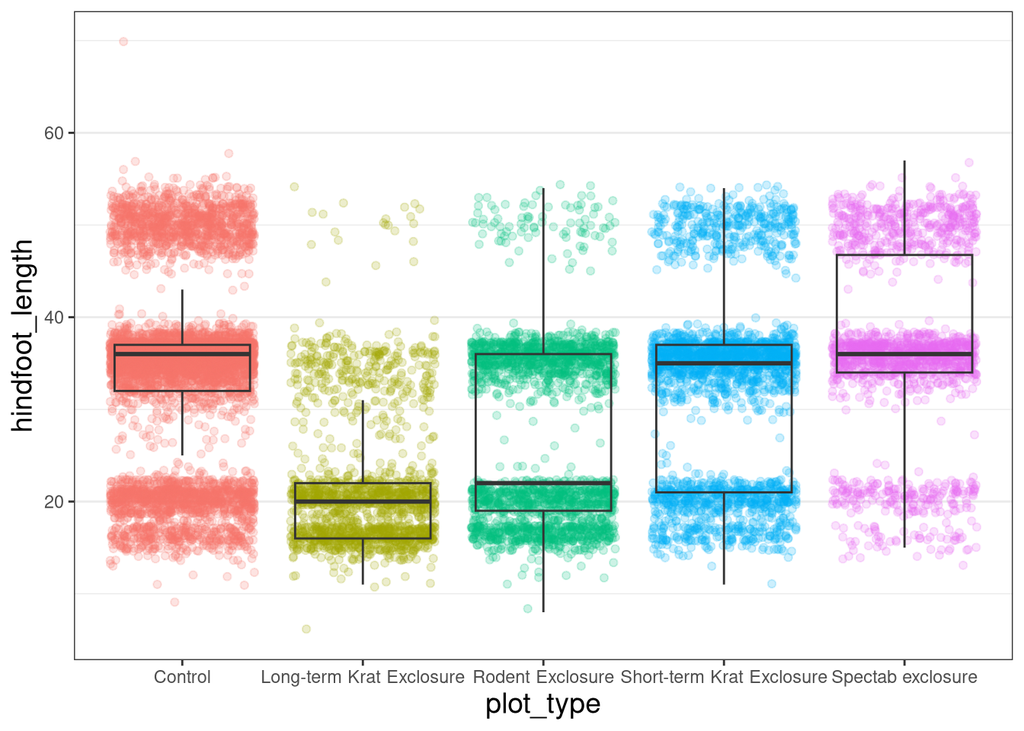

```r
?complete_old

# Add data to R environment
data(complete_old)

# Most recent plot from lesson
ggplot(data = complete_old, mapping = aes(x = plot_type, y = hindfoot_length)) +
  geom_jitter(aes(color = plot_type), alpha = 0.2) +
  geom_boxplot(outlier.shape = NA, fill = NA) +
  theme_bw() +
  theme(axis.title = element_text(size = 14),
        panel.grid.major.x = element_blank(),
        legend.position = "none")
```

These boxplots are not ideal for describing these data The points reveal underlying patterns not accounted for by the boxplots Notice that these data contain observations from multiple species and taxa

```r
?complete_old
unique(complete_old$taxa)
```

```
## [1] "Rodent"  NA        "Rabbit"  "Bird"    "Reptile"
```

```r
unique(complete_old$species_id)
```

```
##  [1] "NL" "DM" "PF" "PE" "DS" "PP" "SH" "OT" "DO" "OX" "SS" "OL" "RM" ""   "SA"
## [16] "PM" "AH" "DX" "AB" "CB" "CM" "CQ" "RF" "PC" "PG" "PH" "PU" "CV" "UR" "UP"
## [31] "ZL" "UL" "CS" "SC" "BA" "SF"
```

Make a barplot of the total counts of each species, then rotate to the x-axis labels to make them more readable.

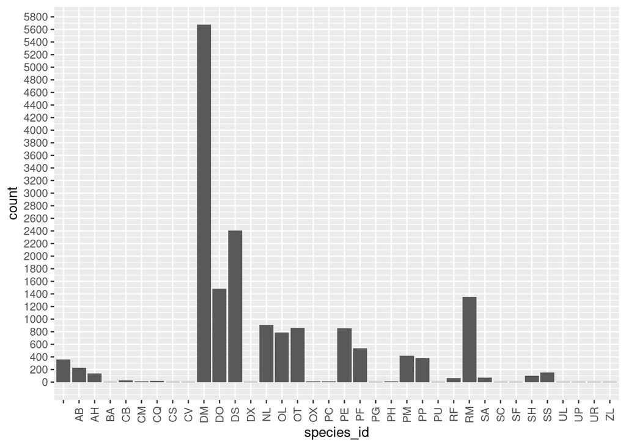

```r
ggplot(data = complete_old, mapping = aes(x = species_id)) +
  geom_bar(stat = "count") +
  scale_y_continuous(breaks = seq(from = 0, to = 6000, by = 200)) +
  theme(axis.text.x = element_text(angle = 90, vjust = 0.5))
```

Now use the fill aesthetic to show the breakdown in counts by sex

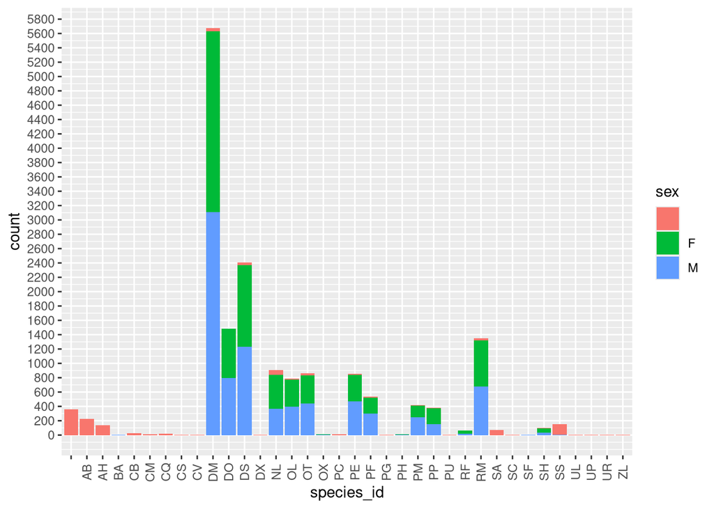

```r
ggplot(data = complete_old, mapping = aes(x = species_id, fill = sex)) +
  geom_bar(stat = "count") +
  scale_y_continuous(breaks = seq(from = 0, to = 6000, by = 200)) +
  theme(axis.text.x = element_text(angle = 90, vjust = 0.5))
```

Lets choose a color palette from RColorBrewer

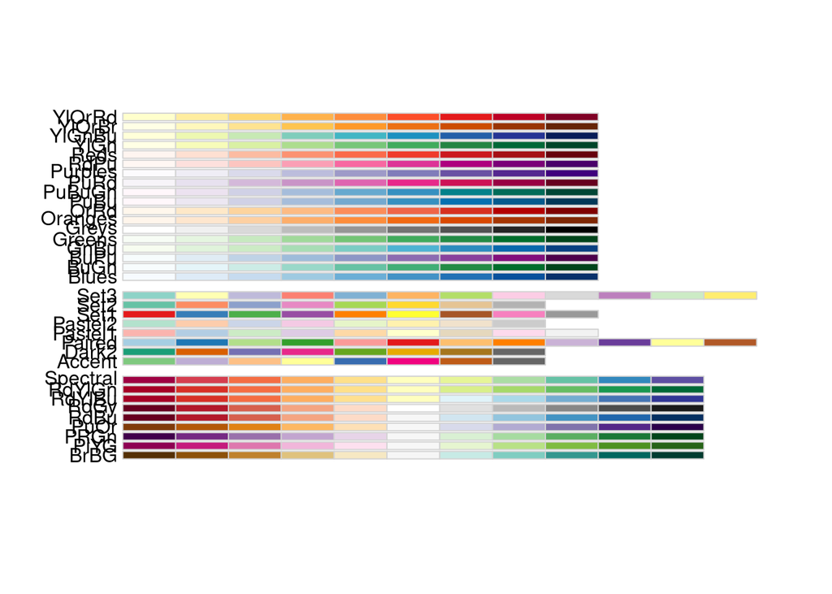

```r
display.brewer.all()
```

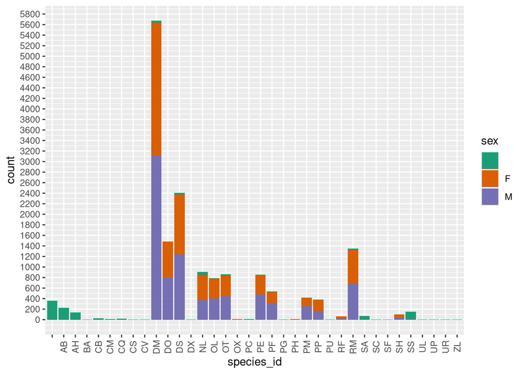

```r
ggplot(data = complete_old, mapping = aes(x = species_id, fill = sex)) +
  geom_bar(stat = "count") +
  scale_y_continuous(breaks = seq(from = 0, to = 6000, by = 200)) +
  theme(axis.text.x = element_text(angle = 90, vjust = 0.5)) +
  scale_fill_brewer(palette = "Dark2")
```

Now add a horizontal line at count = 400

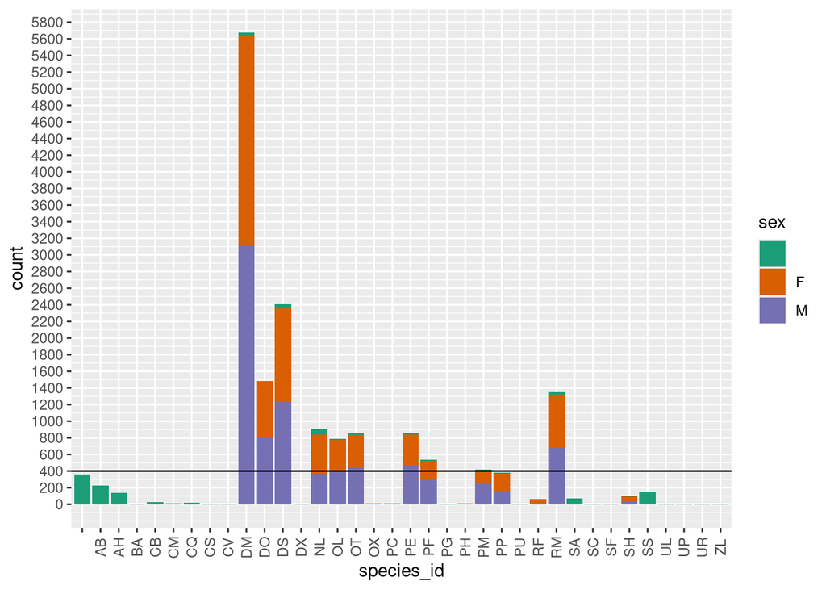

```r
ggplot(data = complete_old, mapping = aes(x = species_id, fill = sex)) +
  geom_bar(stat = "count") +
  scale_y_continuous(breaks = seq(from = 0, to = 6000, by = 200)) +
  theme(axis.text.x = element_text(angle = 90, vjust = 0.5)) +
  scale_fill_brewer(palette = "Dark2") +
  geom_hline(yintercept = 400, col = "black")
```

Look at only the species who occur 400 or more times

```r
species_400 <- complete_old %>%
  group_by(species_id) %>%
  summarise(total_obs = n()) %>%
  dplyr::filter(total_obs >= 400)
```

Subset the data to include only the species occurring 400 or more times

```r
species_400_data <- complete_old %>%
  dplyr::filter(species_id %in% species_400$species_id)
```

Recreate previous boxplots with jittered points, but facet by each species. Don’t suppress the outliers!

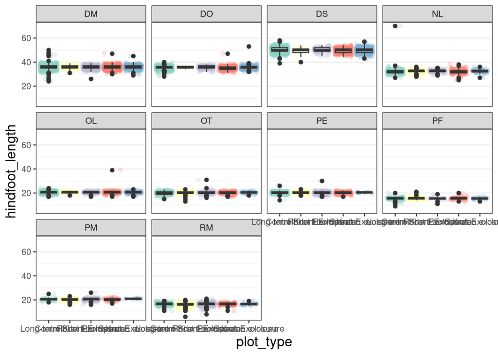

```r
ggplot(data = species_400_data, mapping = aes(x = plot_type, y = hindfoot_length)) +
  geom_jitter(aes(color = plot_type), alpha = 0.2) +
  geom_boxplot(fill = NA) +
  theme_bw() +
  theme(axis.title = element_text(size = 14),
        panel.grid.major.x = element_blank(),
        legend.position = "none") +
  facet_wrap(~species_id) +
  scale_color_brewer(palette = "Set3")
```

Now rotate x-axis label. Allow for different y-axis scale for each species, and extend whiskers to max and mix.

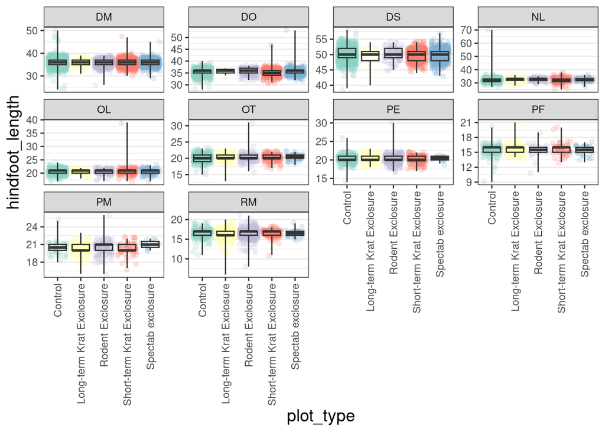

```r
ggplot(data = species_400_data, mapping = aes(x = plot_type, y = hindfoot_length)) +
  geom_jitter(aes(color = plot_type), alpha = 0.2) +
  geom_boxplot(coef= NULL, fill = NA) +
  theme_bw() +
  theme(axis.title = element_text(size = 14),
        panel.grid.major.x = element_blank(),
        legend.position = "none") +
  scale_color_brewer(palette = "Set3") +
  theme(axis.text.x = element_text(angle = 90, vjust = 0.5, hjust = 1)) +
  facet_wrap(~species_id, scales = "free_y")
```

Create a new boxplot figure that lumps all plot_types together but has separate boxplots for each species

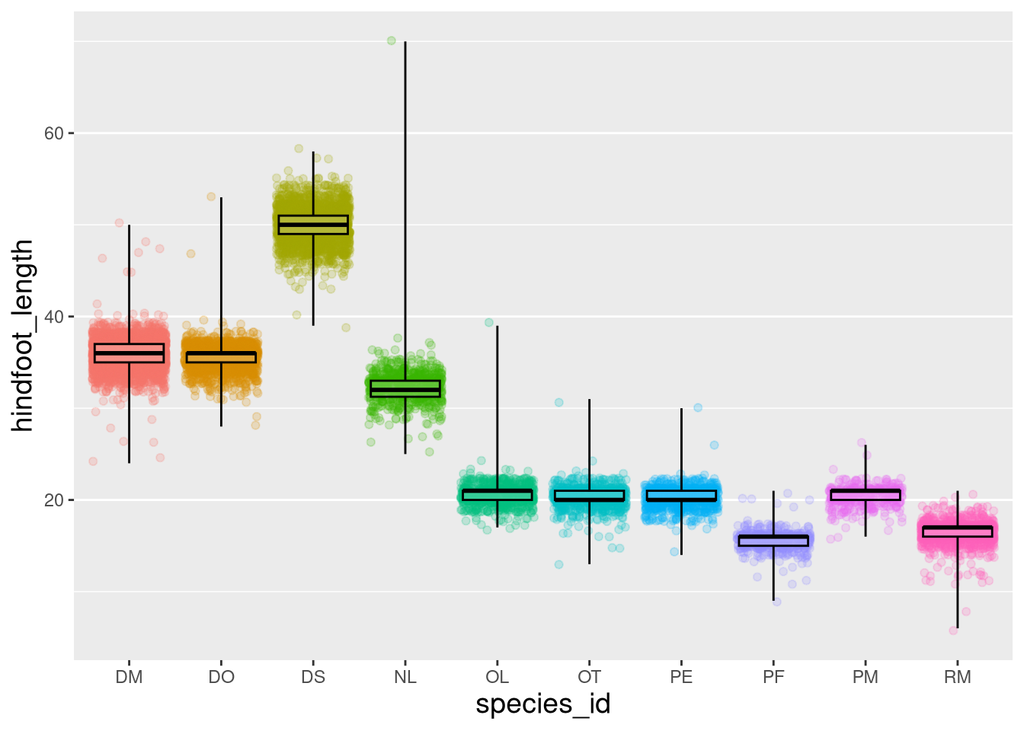

```r
ggplot(data = species_400_data, mapping = aes(x = species_id, y = hindfoot_length, color = species_id)) +
  geom_jitter(alpha = 0.2) +
  geom_boxplot(coef = NULL, col = "black", alpha = 0.2) +
  theme(axis.title = element_text(size = 14),
        panel.grid.major.x = element_blank(),
        legend.position = "none")
```

Subset the Dipodomys species and remove the species identified only to genus. Then, remove the species with unassigned sex and create species name by pasting togther genus and species.

```r
Dipodomys <- complete_old %>%
  dplyr::filter(genus == "Dipodomys") %>%
  dplyr::filter(species != "sp.") %>% # Remove the unidentified individuals
  dplyr::filter(sex != "") %>%
  mutate(species_name = paste(genus, species, sep = " "))

with(Dipodomys, table(species_name))
```

```
## species_name
##    Dipodomys merriami       Dipodomys ordii Dipodomys spectabilis
##                  5630                  1482                  2367
```

```r
unique(Dipodomys$sex)
```

```
## [1] "F" "M"
```

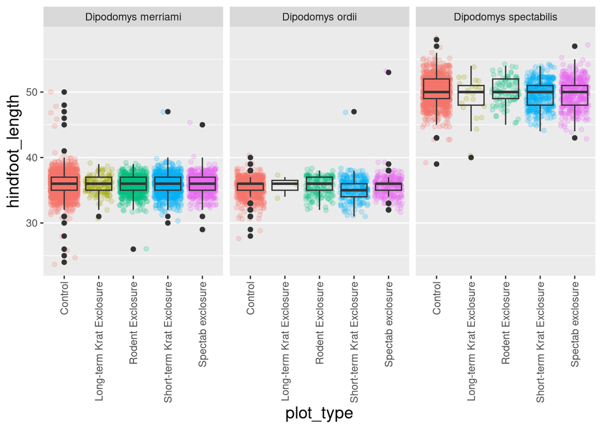

```r
ggplot(data = Dipodomys, mapping = aes(x = plot_type, y = hindfoot_length)) +
  geom_jitter(aes(color = plot_type), alpha = 0.2) +
  geom_boxplot(fill = NA) +
  facet_wrap(~species_name, nrow = 1) +
  theme(axis.text.x = element_text(angle = 90, vjust = 0.5, hjust = 1)) +
  theme(axis.title = element_text(size = 14),
        panel.grid.major.x = element_blank(),
        legend.position = "none")
```

Now transpose the data so that hindfoot_length and weight are in the same column, identified by a new column called “variable”.

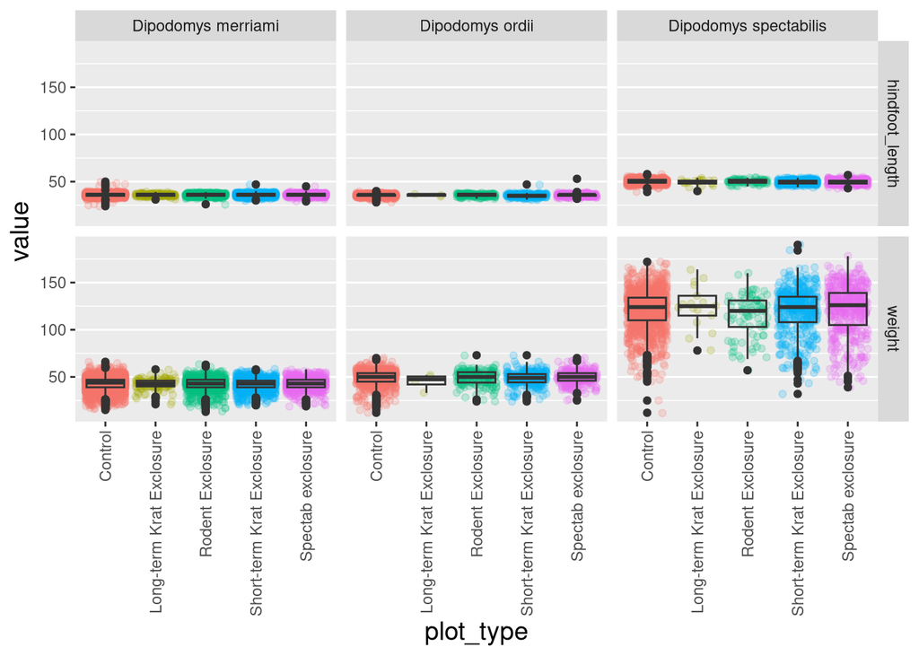

```r
Dipodomys_long <- Dipodomys %>%
  pivot_longer(cols = c(hindfoot_length, weight),
               names_to = "variable",
               values_to = "value")

ggplot(data = Dipodomys_long, mapping = aes(x = plot_type, y = value)) +
  geom_jitter(aes(color = plot_type), alpha = 0.2) +
  geom_boxplot(fill = NA) +
  facet_grid(variable ~ species_name) +
  theme(axis.text.x = element_text(angle = 90, vjust = 0.5, hjust = 1)) +
  theme(axis.title = element_text(size = 14),
        panel.grid.major.x = element_blank(),
        legend.position = "none")
```

Allow for different y-axis scales

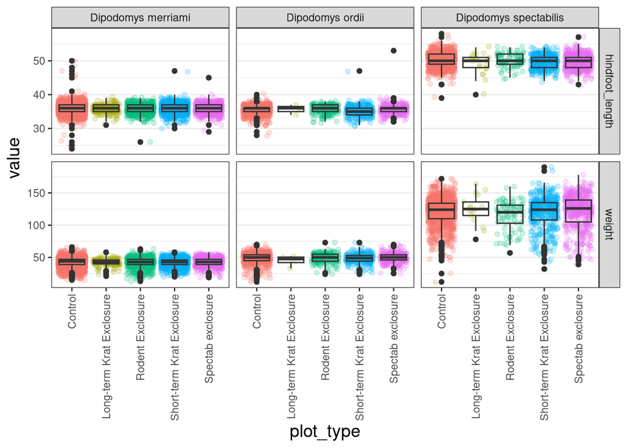

```r
ggplot(data = Dipodomys_long, mapping = aes(x = plot_type, y = value)) +
  theme_bw() +
  geom_jitter(aes(color = plot_type), alpha = 0.2) +
  geom_boxplot(fill = NA) +
  facet_grid(variable ~ species_name, scales = "free_y") +
  theme(axis.text.x = element_text(angle = 90, vjust = 0.5, hjust = 1)) +
  theme(axis.title = element_text(size = 14),
        panel.grid.major.x = element_blank(),
        legend.position = "none")
```

Work with Dipodomys spectabilis (Banner-tailed kangaroo rat)

```r
banner_tailed <- Dipodomys %>%
  dplyr::filter(species_name == "Dipodomys spectabilis")
```

Look at the density of points across weight and hindfoot_length

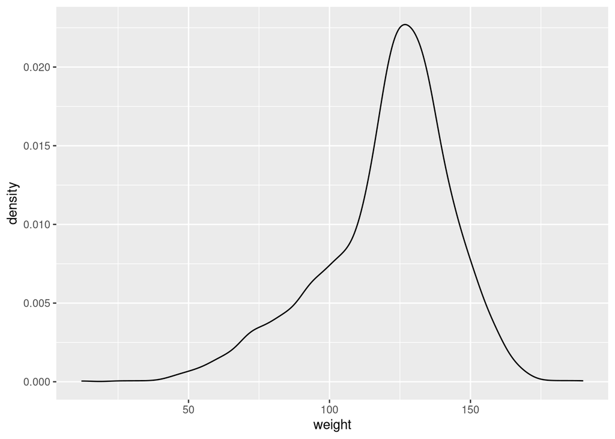

```r
ggplot(banner_tailed, aes(x=weight)) +
  geom_density()
```

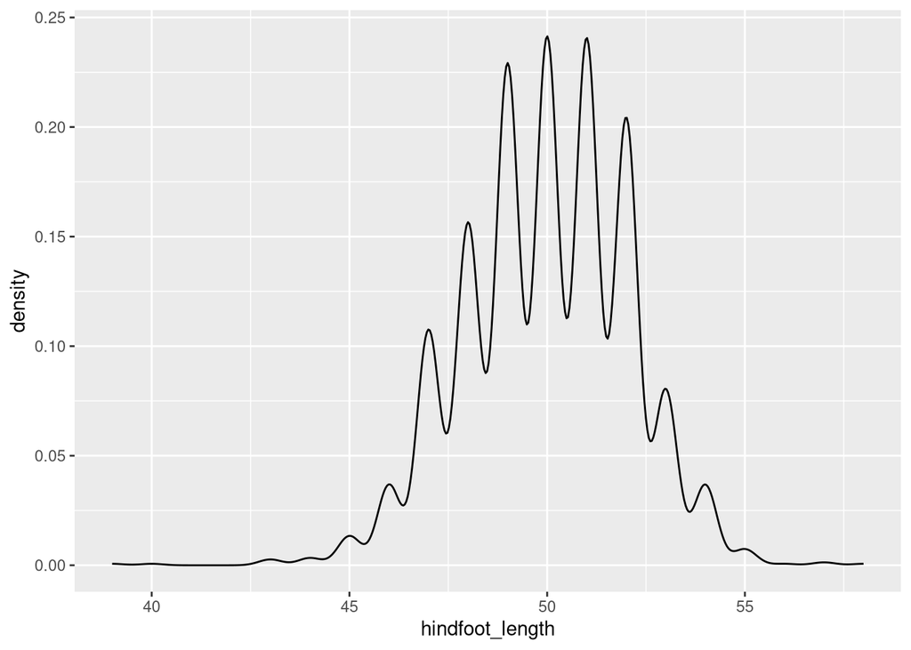

```r
ggplot(banner_tailed, aes(x=hindfoot_length)) +
  geom_density()
```

Weight is continuous but hindfoot_length is discrete

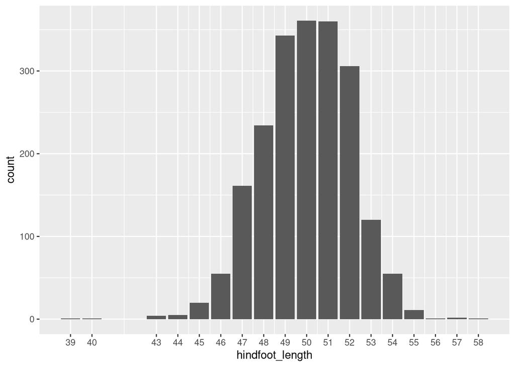

```r
ggplot(banner_tailed, aes(x=hindfoot_length)) +
  geom_bar(state = "count") +
  scale_x_continuous(breaks = unique(banner_tailed$hindfoot_length))
```

Use geom_density_2d to show the density

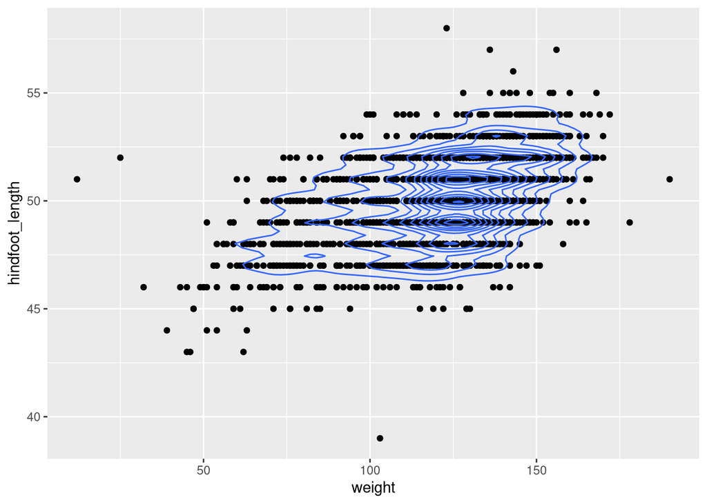

```r
ggplot(banner_tailed , aes(x = weight, y = hindfoot_length)) +
  geom_point() +
  geom_density_2d()
```

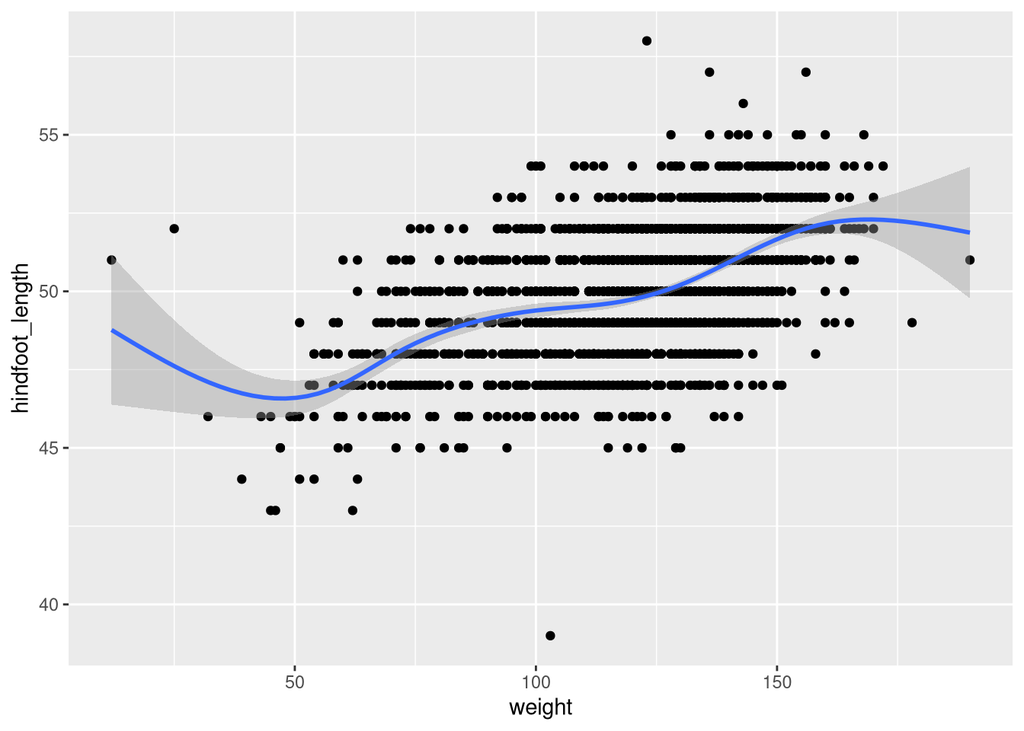

```r
ggplot(banner_tailed, aes(x = weight, y = hindfoot_length)) +
  geom_point() +
  geom_smooth()
```

Linear regression

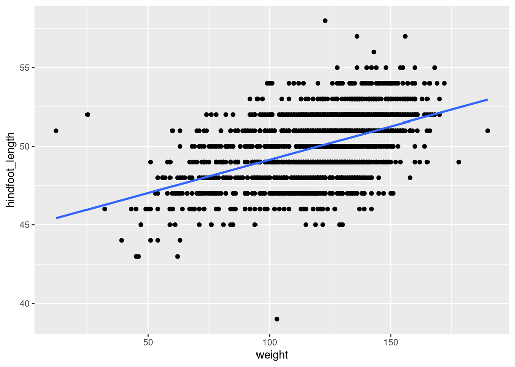

```r
ggplot(banner_tailed, aes(x = weight, y = hindfoot_length)) +
  geom_point() +
  geom_smooth(method = "lm", se = FALSE)
```

Polynomial regression

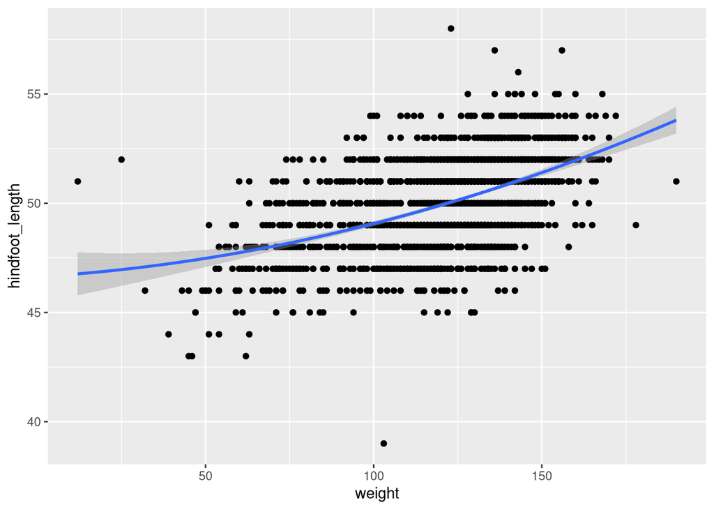

```r
ggplot(banner_tailed, aes(x = weight, y = hindfoot_length)) +
  geom_point() +
  stat_smooth(method='lm', formula = y~poly(x,2))
```

Linear regression with regression equation and summary statistics

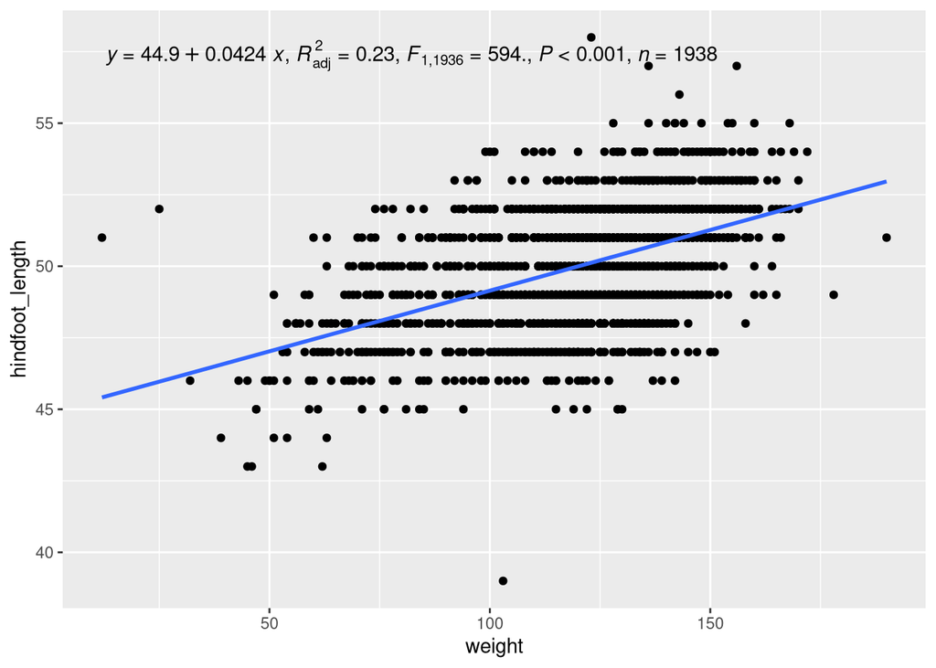

```r
ggplot(banner_tailed, aes(x = weight, y = hindfoot_length)) +
  geom_point() +
  geom_smooth(method = "lm", se = FALSE) +
  stat_poly_eq(use_label(c("eq", "adj.R2", "f", "p", "n")))
```

These regression statistics are consistent with lm() regression function

```r
lm(weight ~ hindfoot_length, data = banner_tailed) %>% summary()
```

```
##
## Call:
## lm(formula = weight ~ hindfoot_length, data = banner_tailed)
##
## Residuals:
##      Min       1Q   Median       3Q      Max
## -113.979  -10.516    3.094   14.094   64.021
##
## Coefficients:
##                  Estimate Std. Error t value Pr(>|t|)
## (Intercept)     -156.3933    11.3708  -13.75   <2e-16 ***
## hindfoot_length    5.5367     0.2271   24.38   <2e-16 ***
## ---
## Signif. codes:  0 '***' 0.001 '**' 0.01 '*' 0.05 '.' 0.1 ' ' 1
##
## Residual standard error: 20.39 on 1936 degrees of freedom
##   (429 observations deleted due to missingness)
## Multiple R-squared:  0.2348, Adjusted R-squared:  0.2344
## F-statistic: 594.1 on 1 and 1936 DF,  p-value: < 2.2e-16
```

Use separate colors for sex

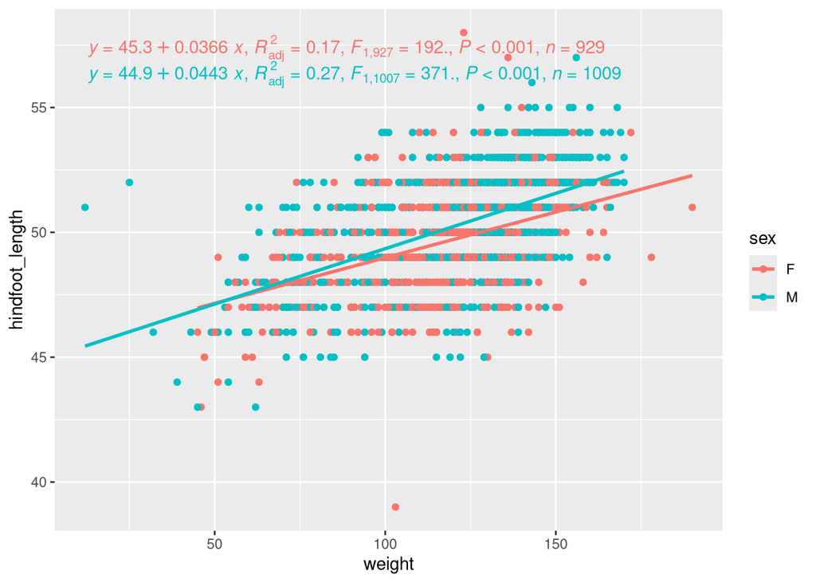

```r
ggplot(banner_tailed, aes(x = weight, y = hindfoot_length, col = sex)) +
  geom_point() +
  geom_smooth(method = "lm", se = FALSE) +
  stat_poly_eq(use_label(c("eq", "adj.R2", "f", "p", "n")))
```

Is there evidence for different slopes between males and females?

```r
lm(weight ~ hindfoot_length*sex, data = banner_tailed) %>% summary()
```

```
##
## Call:
## lm(formula = weight ~ hindfoot_length * sex, data = banner_tailed)
##
## Residuals:
##      Min       1Q   Median       3Q      Max
## -114.958  -10.503    2.902   13.972   65.883
##
## Coefficients:
##                       Estimate Std. Error t value Pr(>|t|)
## (Intercept)          -114.9518    17.4479  -6.588 5.72e-11 ***
## hindfoot_length         4.6876     0.3513  13.344  < 2e-16 ***
## sexM                  -67.6397    23.2678  -2.907  0.00369 **
## hindfoot_length:sexM    1.3820     0.4654   2.969  0.00302 **
## ---
## Signif. codes:  0 '***' 0.001 '**' 0.01 '*' 0.05 '.' 0.1 ' ' 1
##
## Residual standard error: 20.34 on 1934 degrees of freedom
##   (429 observations deleted due to missingness)
## Multiple R-squared:  0.2392, Adjusted R-squared:  0.238
## F-statistic: 202.6 on 3 and 1934 DF,  p-value: < 2.2e-16
```

Use facet_grid to apply regression to all the species in the Dipodomys data.frame Allow for different y-axis scales

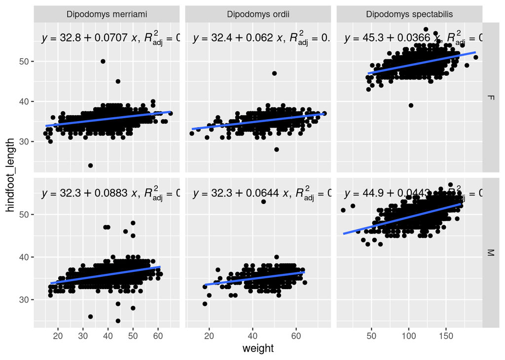

```r
ggplot(Dipodomys, aes(x = weight, y = hindfoot_length)) +
  geom_point(col = "black") +
  geom_smooth(method = "lm", se = FALSE) +
  stat_poly_eq(mapping = use_label("eq", "adj.R2")) +
  # stat_poly_eq(x = 100, y = 60, mapping = use_label("adj.R2", "n")) +
  facet_grid(sex ~ species_name, scales = "free") +
  theme(legend.position = "none")
```